# Mini-project 6 - {ggplot2} extensions

Norma Alejandra Abrena

06/23/2025

This exercise will introduce five {ggplot2} extension packages: `{gghighlight}`, `{ggdist}`, `{ggridges}`, `{patchwork}`, `{cowplot}`

In this Mini-Project we will be looking at some R packages that augment plots created using `{ggplot2}`. One of the great things about learning `{ggplot2}` is that many packages create visualizations that are `{ggplot2}` objects. This means they can be augmented and enhanced using these helper packages.

In this mini project we’ll meet {gghighlight}, {ggdist}, {ggridges}, {patchwork} and {cowplot} but there are *many* others to explore.

## 1. Create a dataset

This dataset is the Analysis Lab Chemistry data from CDISC that was created for training/testing purposes. We are focussing on the Alanine Aminotransferase (ALT) results. We are subsetting only the “Active” phase of study for the `ALT2` dataset. We are calculating a new variable `WEEK` that defines the week within the Analysis Active Treatment Period.

```r
ALT <- import("https://github.com/phuse-org/phuse-scripts/raw/master/data/adam/cdisc/adlbc.xpt") %>%
  filter(PARAMCD == "ALT")

ALT2 <- ALT %>%
  filter(VISITNUM > 3) %>%
  mutate(WEEK = floor(ADY/7))

TREATfac <- ALT2 %>%
  select(TRTA, TRTAN) %>%
  unique() %>%
  arrange(TRTAN) %>%
  mutate(TREATMENT = factor(TRTA, ordered = TRUE))

ALT2 <- ALT2 %>%
  mutate(TREATTXT = factor(TRTP, levels = TREATfac$TRTA))

uniqueVal <- function(x){
  if(length(unique(x))>1) simpleWarning(paste0("More than one value in column:",x))
  unique(x)
}
```

## 2. Create a spaghetti plot of ALT measurements over time

First, let’s show a spaghetti plot of ALT measurements over time (profiles for each subject) and show the Normal Range. Using what we learned in the last mini project, fill in the `mapping` argument for the `ggplot` and `geom_line` statement. We’ll use `ADY` for the x axis and `LBSTRESN` for the y axis. In the `geom_line` we’ll want to connect all values for a given subject by using the `group` attribute.

We’re also going to use the `A1LO` and `A1HI` columns to make a shaded region showing the normal range of values for ALT. The `alpha` argument makes this shaded region more transparent. We want to draw the shaded `geom_ribbon` area *once*, (rather than superimposing the `A1LO` and `A1HI` values from the dataset (which are repeated for every subject). We use the function `uniqueVal` which we defined earlier to pick out a single value for the normal range minimum and maximum values.

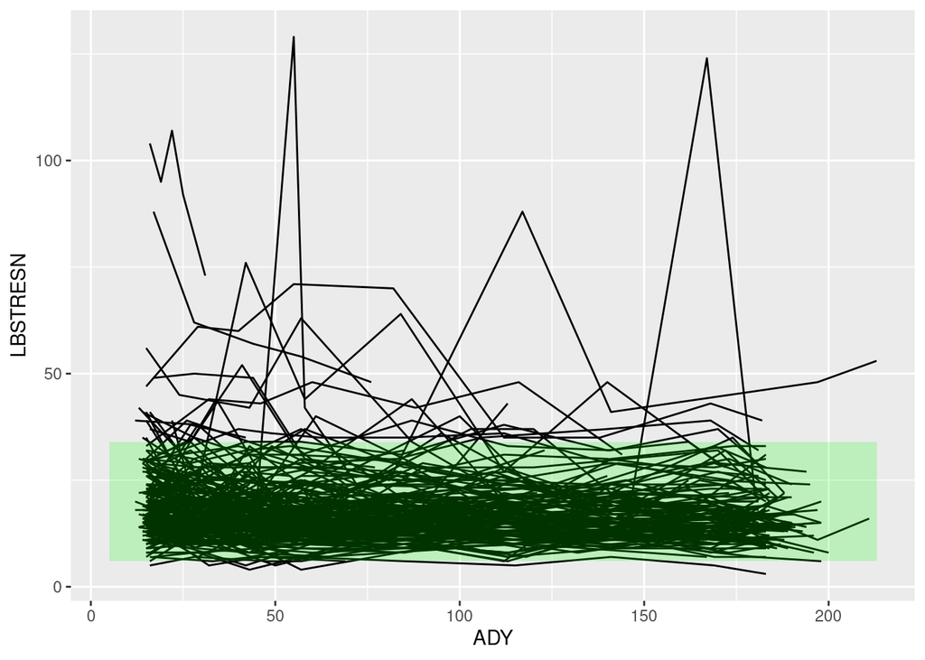

```r
ALTmin <- uniqueVal(ALT2$A1LO)[1]
ALTmax <- uniqueVal(ALT2$A1HI)[1]

plot1 <- ALT2 %>%
  ggplot(mapping = aes(x=ADY, y=LBSTRESN  )) +
  geom_line(mapping = aes(group=USUBJID  )) +
  geom_ribbon(mapping = aes(ymin = ALTmin, ymax = ALTmax), fill = "green", alpha = 0.2)

plot1
```

It’s often useful to do this first plot to see what the data look like before we “tidy” it. Note that there are some VERY high values. Rather than omit these points, we just want to “zoom in” on a narrower range for the y-axis. We introduced this in the last Mini-project.

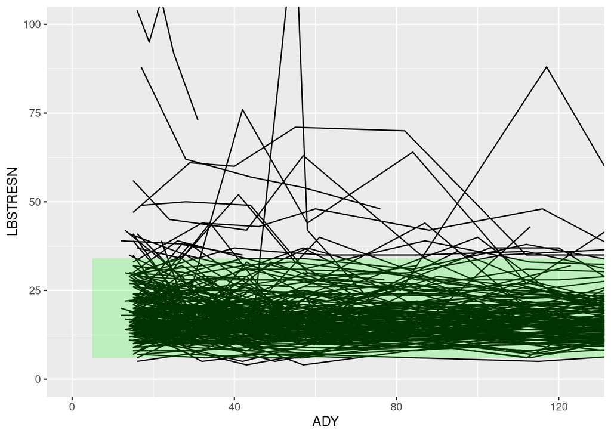

```r
plot1b <- plot1 +
  coord_cartesian(ylim=c(0, 100), xlim = c(0, 125))

plot1b
```

## 3. Using `{gghighlight}`

What would be useful is if we could highlight those subjects whose lab results depart from the normal range. We can do this using the `{gghighlight}` package. `{gghighlight}` takes an existing plot object and highlights values in the plot that match a given predicate (boolean expression). `gghighlight` will make any values NOT matching the predicate fainter / grey so that the remaining values are more obvious. If a group attribute is being used in the plot then it will provide a label to help identify which group(s) are being highlighted in the plot. Here because we have many subjects in the data, it skips showing the label.

```r
library(gghighlight)

plot1c <- plot1b +
  gghighlight::gghighlight(any(LBNRIND == "HIGH" | LBNRIND == "LOW"))
```

```
## label_key: USUBJID
```

```
## Too many data series, skip labeling
```

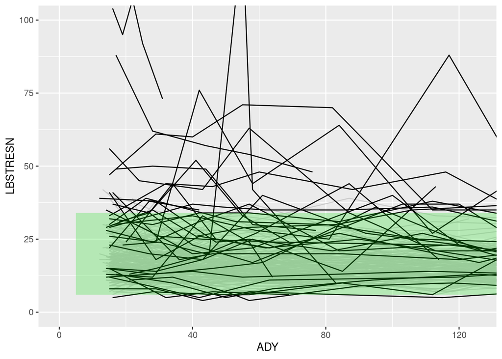

```r
plot1c
```

In order to use facetting with `gghighlight` you need to set the argument `calculate_per_facet` to tell `gghighlight` that you want to highlight values that meet the predicate *within each facet*. Otherwise `gghighlight` will show *ALL* observations within the facet.

```r
plot1d <- plot1b  +
  facet_wrap( ~ TRTP) +
  gghighlight::gghighlight(any(LBNRIND == "HIGH" | LBNRIND == "LOW"),
                           calculate_per_facet = TRUE)
```

```
## label_key: USUBJID
```

```
## Too many data series, skip labeling
```

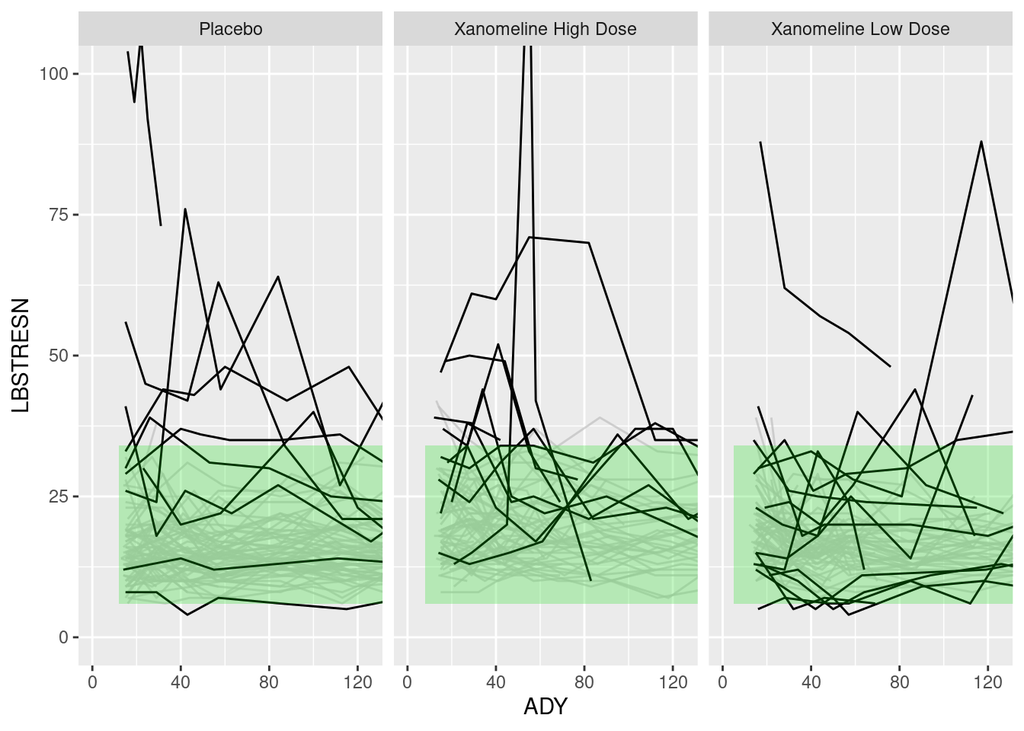

```r
plot1d
```

## 4. Using `geom_boxplot` to visualize distributions

Boxplots give a useful summary of the distribution of values. They show the quartiles, median and range of the data. The problem with boxplots is that they do not show the *number* of values. So in this next plot we are going to try to overlay the data points so that we can see both points and boxplot information.

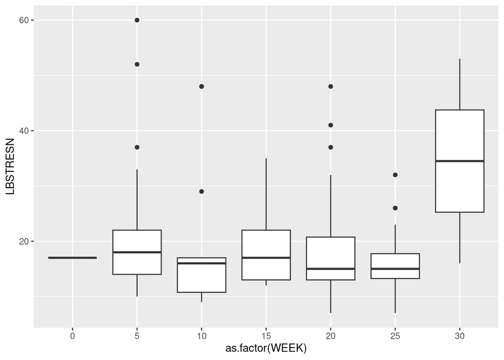

```r
ALT2 %>%
  filter(WEEK %in% c(0, 5, 10, 15, 20, 25, 30)) %>%
  ggplot() +
  geom_boxplot(mapping = aes(x = as.factor(WEEK), y = LBSTRESN))
```

Now let’s add data on top of the boxplots. We can do this quite easily using `geom_point`. Add `mapping` arguments where needed in the code below.

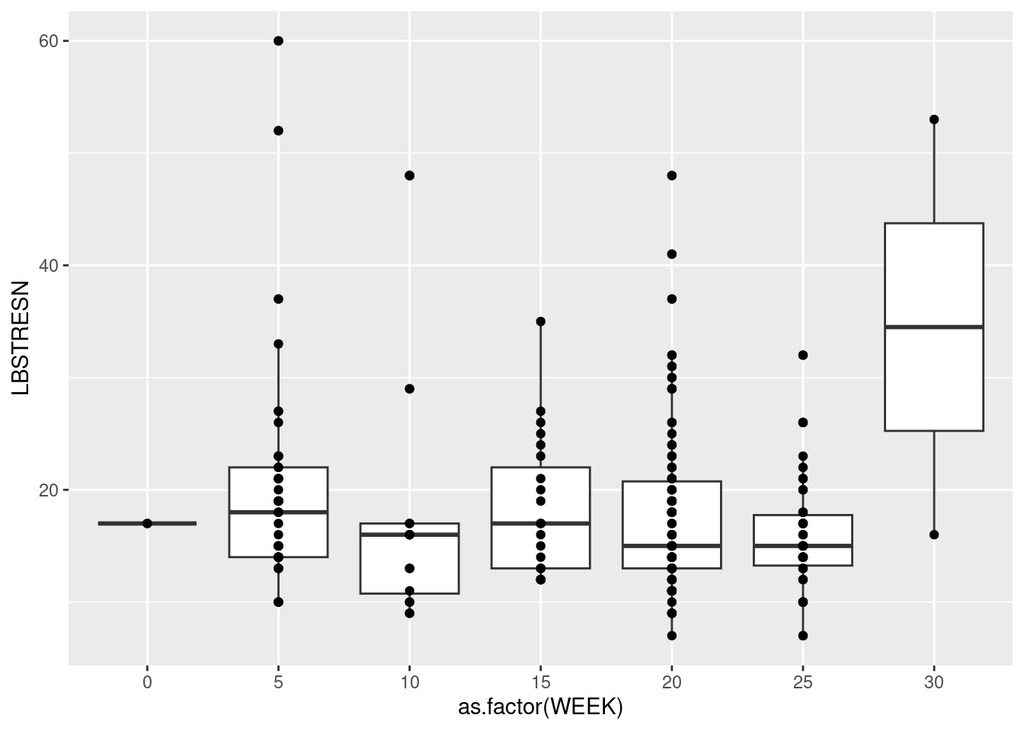

```r
ALT2 %>%
  filter(WEEK %in% c(0, 5, 10, 15, 20, 25, 30)) %>%
  ggplot( mapping = aes(x = as.factor(WEEK), y = LBSTRESN) ) +
  geom_boxplot( ) +
  geom_point( )
```

It might be more useful to spread out the points a little so that we can see individual points. We do this using `geom_jitter`. We can also apply the `alpha` setting to the points to add transparency so we can see the boxplots beneath. The `width` option in `geom_jitter` controls the horizontal jittering of the points. Smaller values will cluster them closer to the middle of the boxplot. The default is to use the full width of the boxplot. Note that in `geom_boxplot` we set the argument `outlier.shape = NA` which will “turn off” showing the outliers, since in this case we show them via `geom_jitter` we don’t need to show them in the boxplot *as well*.

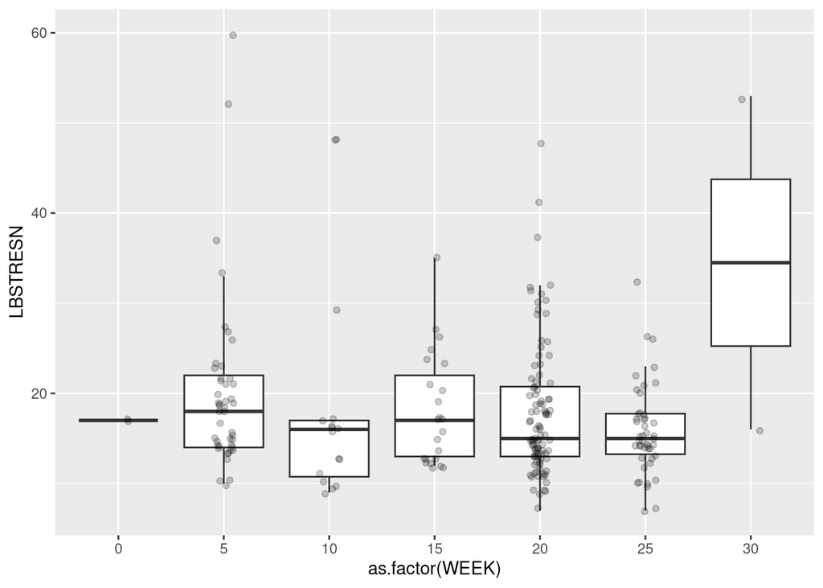

```r
plot2b <- ALT2 %>%
  filter(WEEK %in% c(0, 5, 10, 15, 20, 25, 30) ) %>%
  ggplot(mapping = aes(x = as.factor(WEEK), y = LBSTRESN) ) +
  geom_boxplot( outlier.shape=NA ) +
  geom_jitter(alpha = 0.2, width = 0.1)

plot2b
```

## 5. Showing distributions using other packages

Packages like `{ggdist}` and `{ggridges}` can also be used to show the distribution of values. Each of these packages create `{ggplot2}` objects, which can be annotated and used like any other `{ggplot2}` object. Typically `{ggplot2}` extensions add new `geom_` or `stat_` functions.

Let’s use `{ggdist}` to show dotplots of the data. Because `{ggdist}` shows the distribution of points, it’s often easier to see these horizontally, rather than vertically. In this case we have rotated the plot, putting the continuous ALT value on the x-axis and the week value on the y-axis.

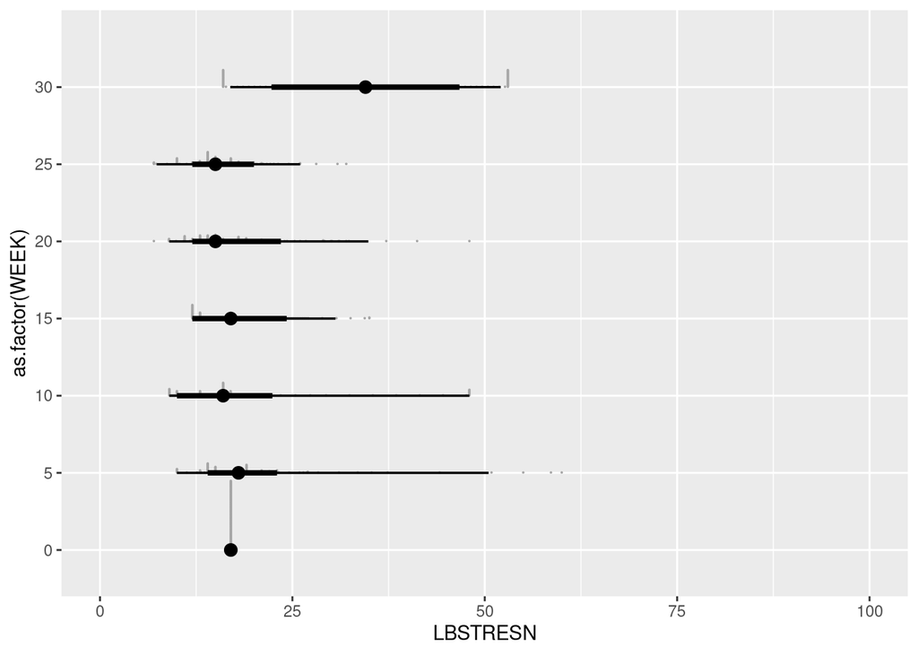

```r
library(ggdist)

ALT2 %>%
  filter(WEEK %in% c(0, 5, 10, 15, 20, 25, 30)) %>%
  ggplot(mapping = aes(x = LBSTRESN, y = as.factor(WEEK))) +
  coord_cartesian(xlim=c(0, 100)) +
  stat_dotsinterval(slab_shape = 19, quantiles = 100)
```

Another option is to show the distribution as a smooth curve, rather than dots. `{ggdist}` has a `stat_slab` geom to help with this. The plot shown below is sometimes called a “raincloud plot” for obvious reasons.

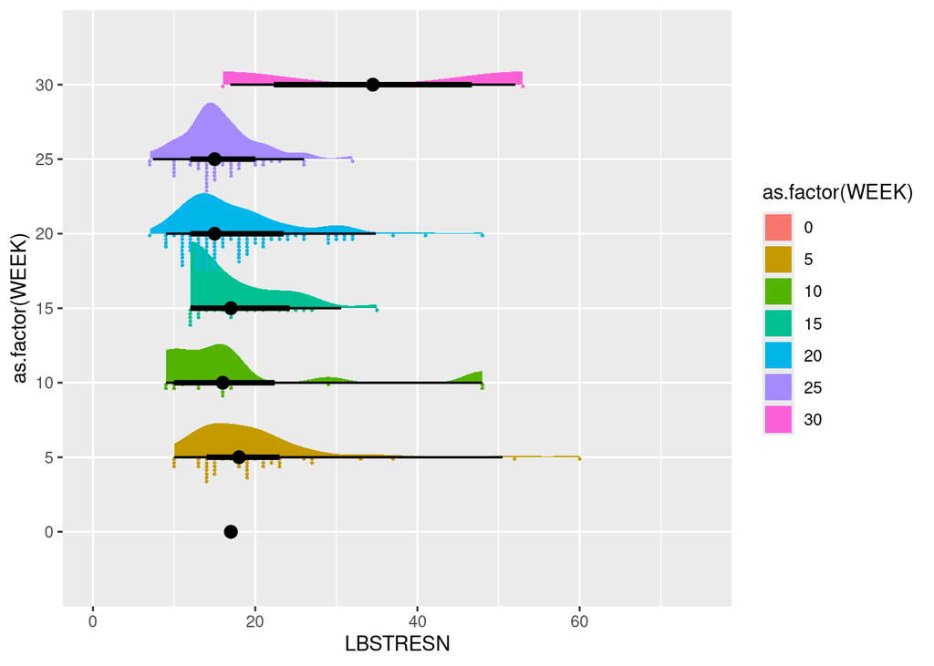

```r
ALT2 %>%
  filter(WEEK %in% c(0, 5, 10, 15, 20, 25, 30)) %>%
  ggplot(mapping = aes(x = LBSTRESN, y = as.factor(WEEK), fill = as.factor(WEEK))) +
  coord_cartesian(xlim=c(0, 75)) +
  stat_slab() +
  stat_dotsinterval(side = "bottom", scale = 0.5, slab_size = NA)
```

The `{ggridges}` package takes this presentation of distributions and slightly overlays the distribution “ridges” to minimise space. The plot allows us to quite readily compare between distributions.

```r
library(ggridges)
```

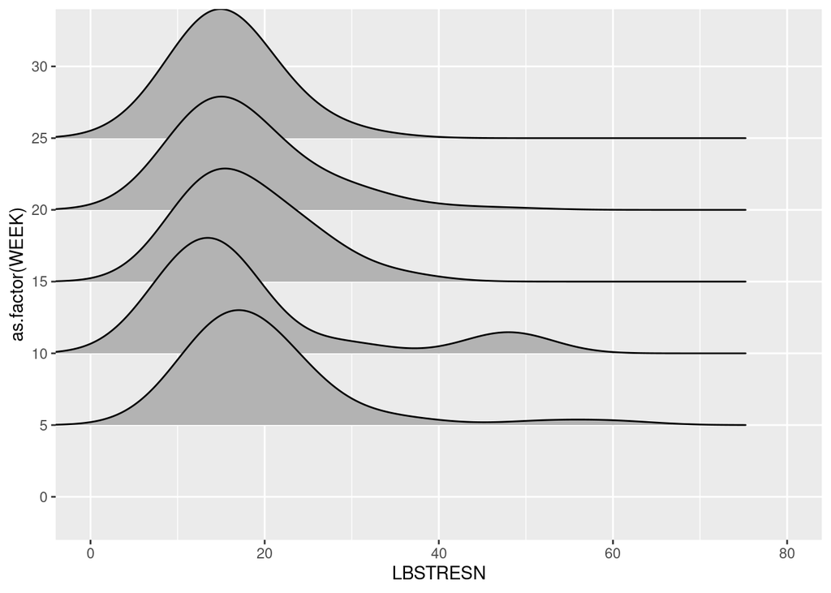

```r
ALT2 %>%
  filter(WEEK %in% c(0, 5, 10, 15, 20, 25, 30)) %>%
  ggplot(mapping = aes(x = LBSTRESN, y = as.factor(WEEK))) +
  coord_cartesian(xlim=c(0, 80)) +
  geom_density_ridges()
```

## 6. Using `geom_bar` to count things

Bar charts can be used to count the number of observations in the data. Let’s use `geom_bar` to visualize the incidence of “Low”, “Normal” and “High” ALT within each week of treatment.

Use the “Data visualization with ggplot2” Cheat Sheet (from the Help menu in RStudio) to see what aesthetics can be specified for `geom_bar` bar chart to show how many observations are in each category of `LBNRIND` across `WEEK`.

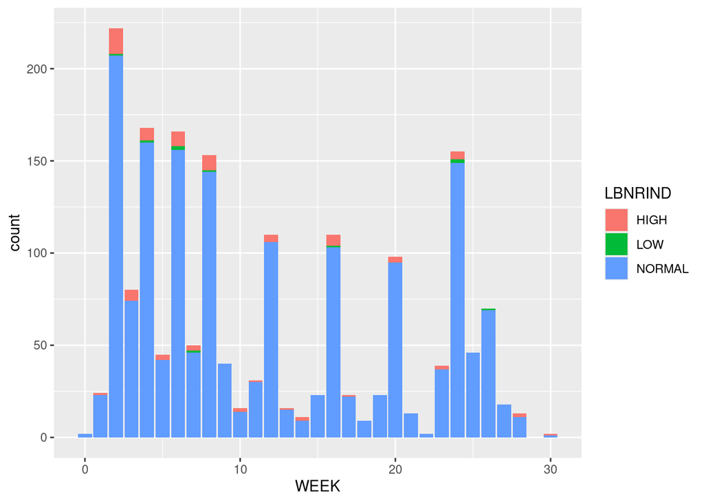

```r
ggplot(ALT2, aes(x = WEEK, fill = LBNRIND)) +
  geom_bar(position = "stack")
```

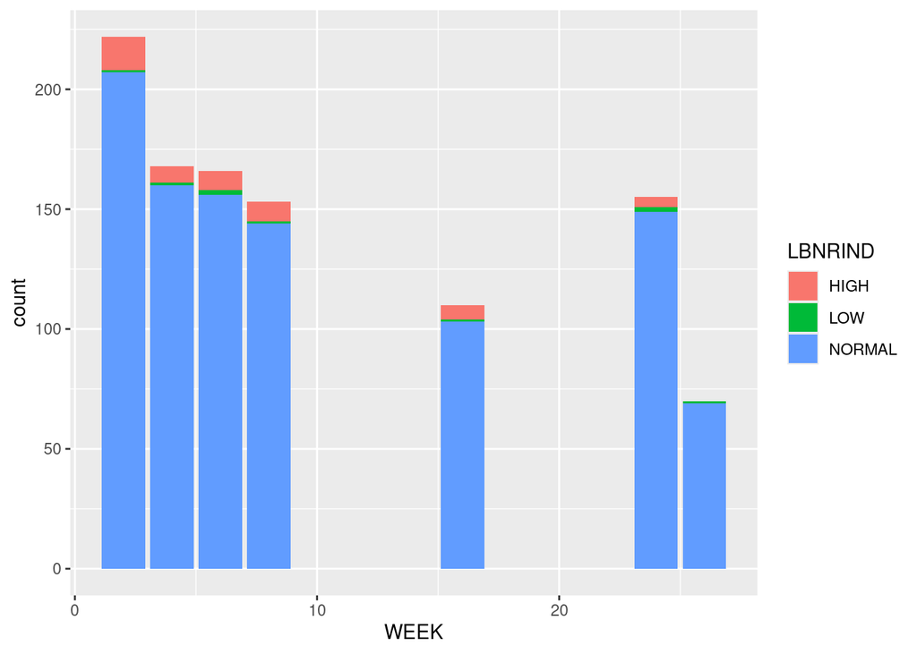

```r
ALT2 %>%
  filter(WEEK %in% c(2, 4, 6, 8, 16, 24, 26)) %>%
  ggplot( ) +
  geom_bar(mapping = aes(x = WEEK,
                         fill = LBNRIND))
```

Once again, we want to convert the `WEEK` variable from continuous to categorical. As above, we can do that with `as.factor`.

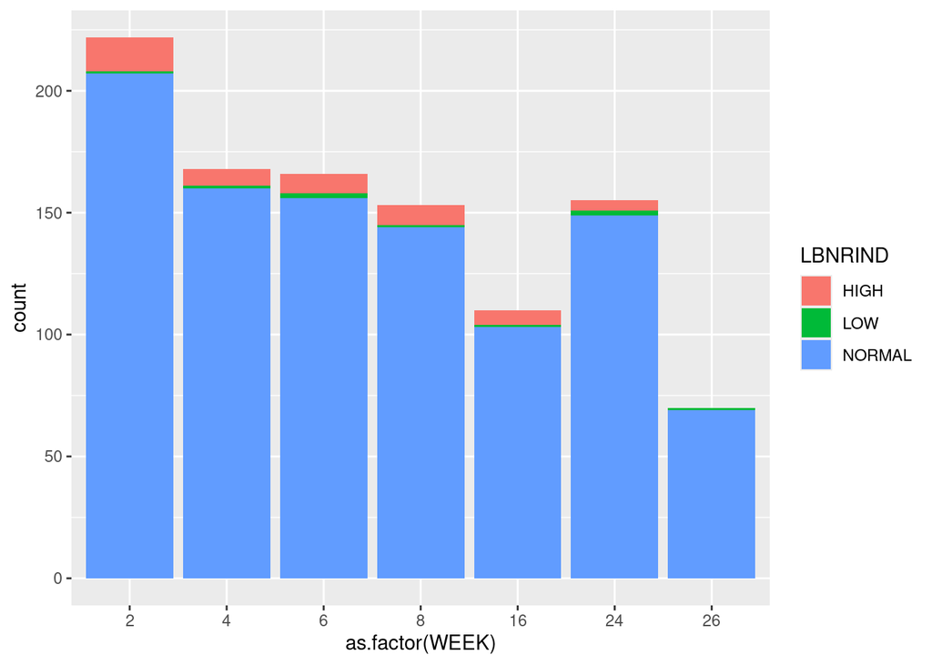

```r
plot3 <- ALT2 %>%
  filter(WEEK %in% c(2, 4, 6, 8, 16, 24, 26)) %>%
  ggplot( ) +
  geom_bar(mapping = aes(x = as.factor(WEEK),
                         fill = LBNRIND))

plot3
```

In a stacked bar chart it’s hard to see exactly how the LOW and HIGH groups change over time as the height of their values is much smaller than the NORMAL observations. We can place the LOW and HIGH separately on the x-axis using the option `position = dodge`. Note that we’re also turning LBNRIND into a factor ordered “LOW” -> “NORMAL” -> “HIGH”. This is because default sorting of character columns is alphanumeric.

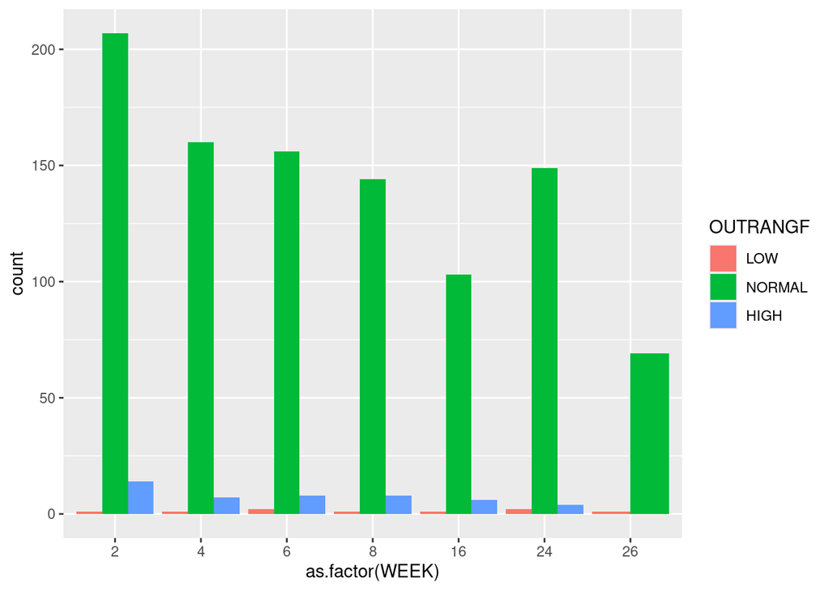

```r
plot3b <- ALT2 %>%
  filter(WEEK %in% c(2, 4, 6, 8, 16, 24, 26)) %>%
  mutate(OUTRANGF = factor(LBNRIND,
                           levels = c("LOW","NORMAL","HIGH"))) %>%
  ggplot() +
  geom_bar(mapping = aes(x = as.factor(WEEK),
                         fill = OUTRANGF),
           position = "dodge")
plot3b
```

As we did in the last mini project, we can now take plots `plot1b` and `plot2b` and apply labels to tidy up axes labels using the `labs` function.

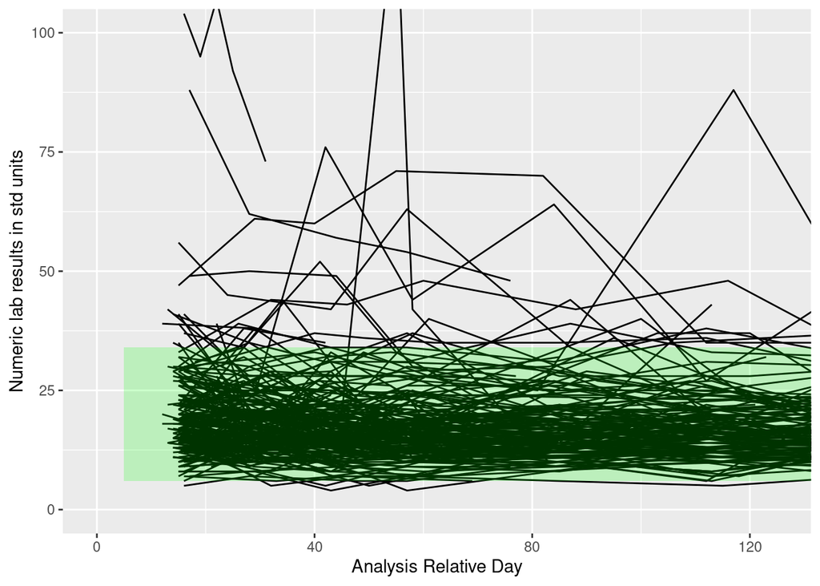

```r
plot1e <- plot1b +
  labs(x = "Analysis Relative Day" ,
       y =  "Numeric lab results in std units" )

plot2c <- plot2b +
  labs(x = "Week" , y = "Numeric lab results in std units"  )

plot3c <- plot3b +
  labs(x = "Week" ,
       y = "Count" )


plot1e
```

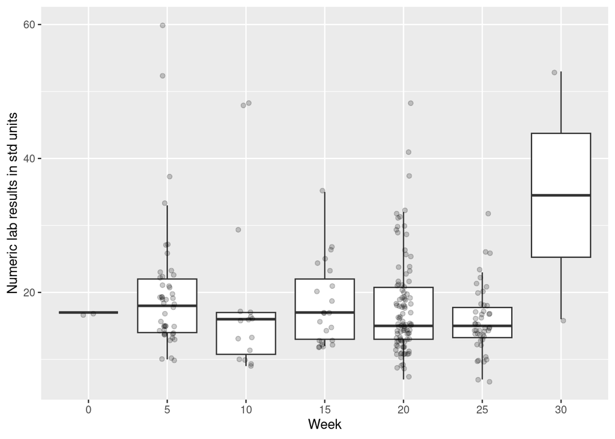

```r
plot2c
```

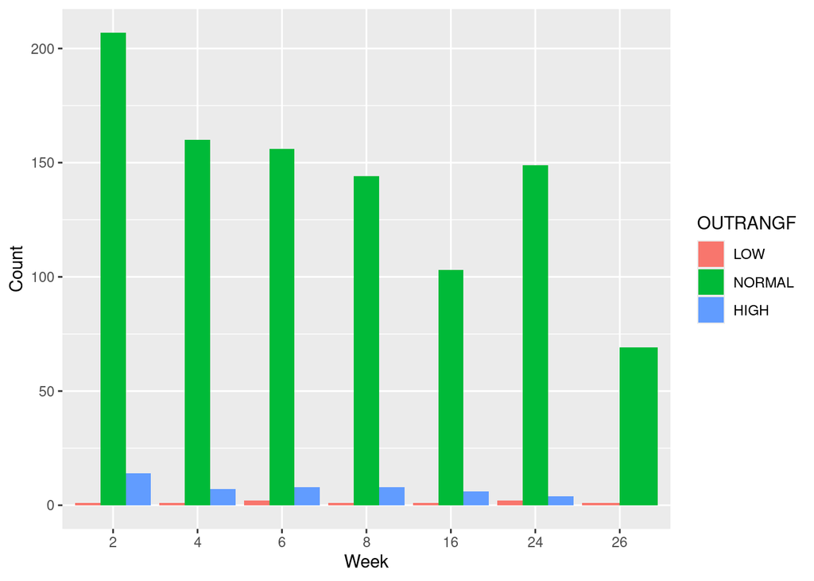

```r
plot3c
```